# Sesión 1 · Estadística Descriptiva

Nivelación Estadística y Probabilidades — Doctorado en Políticas Públicas

Amaru Agüero Jiménez (a.agueroj@udd.cl)

marzo de 2026

## Panorama de la sesión

| Bloque | Concepto clave | Herramienta en R |
| --- | --- | --- |
| Tipos de variables | Nominal, ordinal, discreta, continua | `str()`, `factor()` |
| Tendencia central | Media, mediana, moda, media recortada | `mean()`, `median()` |
| Dispersión | Varianza, DE, IQR, coeficiente de variación | `sd()`, `IQR()` |
| Posición | Cuartiles, z-scores, outliers | `quantile()`, `scale()` |
| Forma | Sesgo y curtosis | `skewness()`, `kurtosis()` |
| Visualización | Histograma, boxplot, dispersión, violín | `ggplot2` |

**Datos de trabajo:** `gapminder` (142 países, año 2007): esperanza de vida, PIB per cápita y población. En políticas públicas, describir bien los datos precede a cualquier evaluación de impacto.

## Tipos de variables: el árbol de decisión

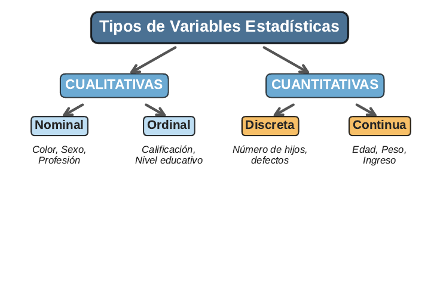

**Ejemplos en políticas públicas y estadístico válido:**

- **Nominal**: región, tipo de establecimiento → moda, proporciones
- **Ordinal**: quintil de ingreso, nivel educativo → mediana, percentiles
- **Discreta**: n° de hijos, delitos por comuna → media, tasas
- **Continua**: ingreso, esperanza de vida → media, DE y todo lo anterior

## Escalas de medición y operaciones válidas

| Escala | ¿Orden? | ¿Distancias? | ¿Cero absoluto? | Ejemplo | Operación NO válida |
| --- | --- | --- | --- | --- | --- |
| Nominal | No | No | No | Partido político | Promediar categorías |
| Ordinal | Sí | No | No | Likert 1–5 | “4 es el doble de 2” |
| Intervalo | Sí | Sí | No | Año, temperatura °C | Cocientes (“el doble de”) |
| Razón | Sí | Sí | Sí | Ingreso, población | — |

La escala determina la técnica: promediar una variable ordinal (p. ej., satisfacción 1–5) asume distancias iguales entre categorías — un supuesto, no un dato. Si la escala es solo ordinal, reporte medianas y proporciones.

## El dataset: 142 países en 2007

```r
glimpse(datos)
```

```
Rows: 142
Columns: 6
$ country   <fct> "Afghanistan", "Albania", "Algeria", "Angola", "Argentina", …
$ continent <fct> Asia, Europe, Africa, Africa, Americas, Oceania, Europe, Asi…
$ year      <int> 2007, 2007, 2007, 2007, 2007, 2007, 2007, 2007, 2007, 2007, …
$ lifeExp   <dbl> 43.828, 76.423, 72.301, 42.731, 75.320, 81.235, 79.829, 75.6…
$ pop       <int> 31889923, 3600523, 33333216, 12420476, 40301927, 20434176, 8…
$ gdpPercap <dbl> 974.5803, 5937.0295, 6223.3675, 4797.2313, 12779.3796, 34435…
```

- `country`, `continent`: **nominales**
- `year`: cuantitativa de **intervalo**
- `lifeExp`, `gdpPercap`: **continuas de razón**
- `pop`: **discreta de razón**

## Tendencia central: tres definiciones de “centro”

**Media**
$$\bar{x} = \frac{1}{n}\sum_{i=1}^{n} x_i$$

- Usa toda la información
- Sensible a outliers
- Base de la inferencia

**Mediana**
$$x_{(n+1)/2}$$

- Parte la muestra en dos mitades
- Robusta a outliers
- Ideal para ingresos

**Moda**

- Valor más frecuente
- Única medida válida para nominales
- Puede no existir o haber varias

```r
c(media = mean(datos$lifeExp), mediana = median(datos$lifeExp),
  media_recortada_10 = mean(datos$lifeExp, trim = 0.10))
```

```
             media            mediana media_recortada_10
          67.00742           71.93550           68.11489
```

## La media es frágil: un solo punto la arrastra

[interactive chart not shown]

Un outlier (3% de los datos) desplaza la media un 30%; la mediana casi no se mueve. Por eso los ingresos se reportan con **medianas**.

## Media vs mediana: diagnóstico de asimetría

```r
media <- mean(datos$lifeExp)
mediana <- median(datos$lifeExp)
round(c(media = media, mediana = mediana,
        diferencia = media - mediana), 2)
```

```
     media    mediana diferencia
     67.01      71.94      -4.93
```

- Media **<** mediana → cola izquierda (sesgo negativo)
- Media **>** mediana → cola derecha (sesgo positivo)
- Media ≈ mediana → distribución simétrica

[interactive chart not shown]

## Medidas de dispersión: cuánto varían los datos

| Medida | Fórmula | Unidad | Robusta |
| --- | --- | --- | --- |
| Varianza | $s^2 = \frac{1}{n-1}\sum (x_i - \bar{x})^2$ | unidades² | No |
| Desviación estándar | $s = \sqrt{s^2}$ | original | No |
| Rango | $\max - \min$ | original | No |
| Rango intercuartílico | $IQR = Q_3 - Q_1$ | original | **Sí** |
| Coef. de variación | $CV = s / \bar{x} \times 100$ | % (adimensional) | No |

```r
round(c(sd = sd(datos$gdpPercap), IQR = IQR(datos$gdpPercap),
        rango = diff(range(datos$gdpPercap))), 0)
```

```
   sd   IQR rango
12860 16384 49080
```

Dos poblaciones pueden compartir la media y ser radicalmente distintas en dispersión — y la dispersión es, muchas veces, el problema de política (desigualdad).

## Misma media, distinta historia

[interactive chart not shown]

Una transferencia plana beneficia igual a ambas comunas; una focalizada requiere conocer la **dispersión**.

## Cuartiles: la anatomía del boxplot

[interactive chart not shown]

La caja concentra el 50% central de los países; todo punto sobre $Q_3 + 1.5 \cdot IQR$ se marca como **outlier**.

## Coeficiente de variación: comparar lo incomparable

```r
cv <- function(x) sd(x) / mean(x) * 100
round(c(cv_pib = cv(datos$gdpPercap),
        cv_vida = cv(datos$lifeExp)), 1)
```

```
 cv_pib cv_vida
  110.1    18.0
```

[interactive chart not shown]

## Z-scores: ¿qué tan lejos del promedio?

$$z_i = \frac{x_i - \bar{x}}{s} \quad \Rightarrow \quad \text{"a cuántas DE está } x_i \text{ de la media"}$$

```r
datos <- datos %>% mutate(z_vida = (lifeExp - mean(lifeExp)) / sd(lifeExp))
datos %>% filter(abs(z_vida) > 2) %>%
  select(country, continent, lifeExp, z_vida) %>%
  arrange(z_vida) %>% mutate(z_vida = round(z_vida, 2))
```

```
# A tibble: 6 × 4
  country      continent lifeExp z_vida
  <fct>        <fct>       <dbl>  <dbl>
1 Swaziland    Africa       39.6  -2.27
2 Mozambique   Africa       42.1  -2.06
3 Zambia       Africa       42.4  -2.04
4 Sierra Leone Africa       42.6  -2.02
5 Lesotho      Africa       42.6  -2.02
6 Angola       Africa       42.7  -2.01
```

Con |z| > 2 detectamos los casos extremos: todos los países con esperanza de vida extremadamente baja en 2007 están en África subsahariana.

## Outliers por regla IQR: código y resultado

```r
Q1 <- quantile(datos$gdpPercap, .25)
Q3 <- quantile(datos$gdpPercap, .75)
lim <- Q3 + 1.5 * IQR(datos$gdpPercap)
datos %>% filter(gdpPercap > lim) %>%
  select(country, gdpPercap) %>%
  arrange(desc(gdpPercap)) %>% head(5)
```

```
# A tibble: 4 × 2
  country       gdpPercap
  <fct>             <dbl>
1 Norway           49357.
2 Kuwait           47307.
3 Singapore        47143.
4 United States    42952.
```

**Protocolo ante un outlier**

1. **Verificar**: ¿error de digitación o valor real?
2. **Documentar**: nunca eliminar en silencio.
3. **Analizar con y sin**: reportar sensibilidad.
4. **Usar medidas robustas**: mediana, IQR, media recortada.

## Histograma: la forma de la distribución

```r
ggplot(datos, aes(x = lifeExp)) +
  geom_histogram(bins = 20,
                 fill = celeste,
                 color = "white") +
  geom_vline(xintercept = media,
             color = rojo,
             linetype = "dashed",
             linewidth = 1) +
  labs(x = "Esperanza de vida (años)",
       y = "N° de países")
```

El número de `bins` cambia la historia: probar 2–3 valores antes de interpretar.

[interactive chart not shown]

## Boxplot comparativo: distribución por grupos

```r
ggplot(datos,
       aes(x = continent, y = gdpPercap,
           fill = continent)) +
  geom_boxplot(alpha = .7,
               outlier.color = rojo) +
  geom_jitter(width = .15, alpha = .3,
              size = 1) +
  scale_y_log10(labels = scales::comma) +
  labs(x = NULL, y = "PIB pc (USD, log)") +
  theme(legend.position = "none")
```

Compara **mediana, dispersión y outliers** de 5 grupos a la vez — imposible con una tabla de medias.

[interactive chart not shown]

## Dispersión: la relación entre dos variables

```r
ggplot(datos,
       aes(x = gdpPercap, y = lifeExp,
           size = pop, color = continent)) +
  geom_point(alpha = .7) +
  scale_x_log10(labels = scales::comma) +
  scale_size(range = c(1, 12),
             guide = "none") +
  labs(x = "PIB pc (USD, log)",
       y = "Esperanza de vida (años)",
       color = NULL) +
  theme(legend.position = "bottom")
```

Relación **logarítmica**: cada duplicación del PIB se asocia a una ganancia similar en años de vida.

[interactive chart not shown]

## Violín + boxplot: densidad y resumen a la vez

```r
ggplot(datos,
       aes(x = continent, y = lifeExp,
           fill = continent)) +
  geom_violin(alpha = .5, color = NA) +
  geom_boxplot(width = .15,
               fill = "white", alpha = .8) +
  labs(x = NULL,
       y = "Esperanza de vida (años)") +
  theme(legend.position = "none")
```

El violín muestra lo que el boxplot esconde: **bimodalidad** dentro de África (dos grupos de países claramente distintos).

[interactive chart not shown]

## ¿Qué gráfico usar? Decisión según tipo de variable

| Pregunta | Variables | Gráfico |
| --- | --- | --- |
| ¿Cómo se distribuye X? | 1 continua | Histograma, densidad |
| ¿Difiere X entre grupos? | 1 continua + 1 nominal | Boxplot, violín |
| ¿Se asocian X e Y? | 2 continuas | Dispersión (+ escala log si hay sesgo) |
| ¿Cómo se reparte una categoría? | 1 nominal | Barras (nunca torta con >4 categorías) |
| ¿Cómo evoluciona X? | continua + tiempo | Líneas |

Errores frecuentes: truncar el eje Y en gráficos de barras, usar torta para comparar magnitudes similares, graficar medias sin mostrar dispersión.

## Tabla resumen por grupo: el estándar de reporte

```r
datos %>% group_by(continent) %>%
  summarise(n = n(), media = mean(lifeExp), mediana = median(lifeExp),
            de = sd(lifeExp), iqr = IQR(lifeExp), cv = sd(lifeExp)/mean(lifeExp)*100) %>%
  mutate(across(where(is.numeric), ~round(.x, 1))) %>%
  kable()
```

| continent | n | media | mediana | de | iqr | cv |
| --- | --- | --- | --- | --- | --- | --- |
| Africa | 52 | 54.8 | 52.9 | 9.6 | 11.6 | 17.6 |
| Americas | 25 | 73.6 | 72.9 | 4.4 | 4.6 | 6.0 |
| Asia | 33 | 70.7 | 72.4 | 8.0 | 10.2 | 11.3 |
| Europe | 30 | 77.6 | 78.6 | 3.0 | 4.8 | 3.8 |
| Oceania | 2 | 80.7 | 80.7 | 0.7 | 0.5 | 0.9 |

## Sesgo y curtosis: cuantificar la forma

```r
round(c(sesgo_pib = skewness(datos$gdpPercap),
        curtosis_pib = kurtosis(datos$gdpPercap),
        sesgo_vida = skewness(datos$lifeExp)), 2)
```

```
   sesgo_pib curtosis_pib   sesgo_vida
        1.21         3.30        -0.68
```

- Sesgo > 0: cola derecha; < 0: cola izquierda
- Curtosis > 3: colas más pesadas que la normal
- Normal de referencia: sesgo 0, curtosis 3

[interactive chart not shown]

## Transformación logarítmica: domar el sesgo

[interactive chart not shown]

El logaritmo comprime la cola derecha y convierte diferencias absolutas en **relativas** — la métrica natural para ingresos y precios.

## Correlación: Pearson mide relaciones lineales

```r
round(c(
  pearson = cor(datos$gdpPercap, datos$lifeExp),
  pearson_log = cor(log(datos$gdpPercap),
                    datos$lifeExp),
  spearman = cor(datos$gdpPercap, datos$lifeExp,
                 method = "spearman")), 3)
```

```
    pearson pearson_log    spearman
      0.679       0.809       0.857
```

- Pearson sube de **0.68 a 0.81** al usar log: la relación es lineal en logs.
- Spearman (rangos) ya la captura sin transformar: robusto a no-linealidad monótona.
- Correlación **no** implica causalidad: países ricos también invierten más en salud y educación.

$r$ solo mide asociación **lineal**: $r \approx 0$ no descarta una relación fuerte no lineal (p. ej., una U invertida). Siempre graficar antes de calcular.

## Caso: brechas entre continentes

```r
datos %>% group_by(continent) %>%
  summarise(vida = mean(lifeExp), pib = mean(gdpPercap)) %>%
  mutate(brecha_vida = round(vida - max(vida), 1),
         brecha_pib = round(pib - max(pib), 0),
         across(c(vida, pib), ~round(.x, 1))) %>% kable()
```

| continent | vida | pib | brecha_vida | brecha_pib |
| --- | --- | --- | --- | --- |
| Africa | 54.8 | 3089.0 | -25.9 | -26721 |
| Americas | 73.6 | 11003.0 | -7.1 | -18807 |
| Asia | 70.7 | 12473.0 | -10.0 | -17337 |
| Europe | 77.6 | 25054.5 | -3.1 | -4756 |
| Oceania | 80.7 | 29810.2 | 0.0 | 0 |

## Errores comunes en estadística descriptiva

| Error | Consecuencia | Corrección |
| --- | --- | --- |
| Reportar media de ingresos | Sobreestima el “caso típico” | Mediana + IQR |
| Promediar escalas ordinales | Asume distancias iguales | Mediana, proporciones |
| Eliminar outliers sin documentar | Resultados no reproducibles | Análisis de sensibilidad |
| Comparar DE entre unidades distintas | Comparación sin sentido | Coeficiente de variación |
| Tabla de medias sin n ni DE | Oculta precisión y dispersión | n, media, DE, mediana |
| Interpretar r como causalidad | Conclusiones de política erradas | Diseños causales (curso de econometría) |

## Síntesis: qué debe salir en su reporte

**Checklist del análisis descriptivo**

1. Clasificar cada variable (tipo y escala)
2. n, media, mediana, DE, IQR **por grupo**
3. Histograma o densidad de las variables clave
4. Boxplot/violín para comparaciones entre grupos
5. Outliers identificados y documentados
6. Transformaciones justificadas (log para sesgo)
7. Correlaciones acompañadas de su gráfico

**Funciones R de esta sesión**

`mean()` `median()` `sd()` `var()` `IQR()` `quantile()` `scale()` `cor()` `skewness()` `kurtosis()` `summarise()` `group_by()` `geom_histogram()` `geom_boxplot()` `geom_violin()` `geom_point()`

**Próxima sesión:** probabilidad condicional y Teorema de Bayes.

## Ejercicio para practicar (30 min)

Con `gapminder` filtrado al año **1977**:

1. Clasifique las 6 variables por tipo y escala.
2. Calcule media, mediana, DE, IQR y CV de `gdpPercap` por continente. ¿Qué continente es más desigual en términos relativos?
3. Detecte outliers de `pop` con la regla IQR. ¿Elimina o conserva? Justifique.
4. Construya el scatter PIB–esperanza de vida con escala log. ¿Se mantiene el patrón de 2007?
5. Compare `cor()` de Pearson y Spearman con y sin log. Explique las diferencias.

**Referencias:** Wickham & Grolemund, *R for Data Science* (cap. 7, EDA) · Illowsky & Dean, *Introductory Statistics* (caps. 1–2) · Documentación de `gapminder` y `ggplot2`.